# Linear Model Report

## Model Comparison

Two linear models were constructed to investigate the influences on teaching evaluation ratings. The first model contained only instructor beauty ratings as a predictor, and teaching evaluation ratings as the outcome ($R^2 = .04$, $F(1, 461) = 17.08$, $p < .001$). The second model added instructor gender as a second predictor with no interaction, both again predicting teaching evaluation ratings ($R^2 = .07$, $F(2, 460) = 16.33$, $p < .001$).

An ANOVA comparing the models indicated a significant improvement in model fit for the second model compared to the first (F(1, 460) = 15.06, p < .001).

## Assumptions Checks

We next assessed the model with two predictors for any evidence of bias. Residual plots (Figure 1) did not indicate any outstanding issues with normality, linearity, or heteroscedasticity. There was also no evidence of influential cases, as the max value of Cook’s distance was 0.03.

Robust models were also fitted as sensitivity checks. Robust parameter estimates estimated using the {robust} package were minimally different from the unadjusted parameter estimates. Similarly, robust HC4 standard errors estimated using the {parameters} package yielded confidence intervals and p-values very similar to the unadjusted values. Therefore, we will proceed with the unadjusted two-predictor model as our final model.

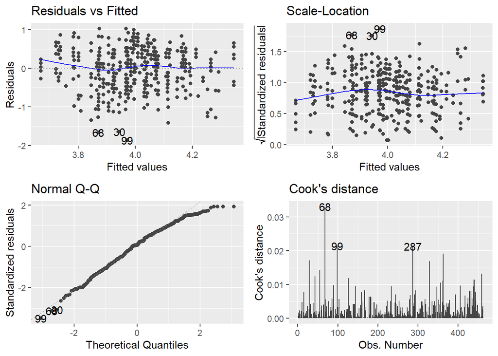

Figure 1: Diagnostic plots for the two-predictor model

## The Final Model

The final model with two predictors is presented in full in Table 1.

Table 1: The final model predicting teaching evaluation ratings from instructor beauty and gender.

| Predictor | $b$ | 95% CI | $t$ | $\mathit{df}$ | $p$ |
| --- | --- | --- | --- | --- | --- |
| Intercept | 3.88 | [3.81, 3.96] | 100.47 | 460 | < .001 |
| Beauty | 0.15 | [0.09, 0.21] | 4.65 | 460 | < .001 |
| Gendermale | 0.20 | [0.10, 0.30] | 3.88 | 460 | < .001 |